# 11.4 数据的相关性分析与数据回归（入门）

> **为什么学？**  
> 在人文社科研究里，你会经常问：*学习时间和成绩有关系吗？收入与幸福感如何相关？*  
> **相关性分析**回答“变量是否一起变化”，**回归分析**进一步建立“如何变化”的**预测关系**。

## 学习目标

- 认识皮尔逊相关系数 `r ∈ [-1,1]` 的含义与解释方式。
- 会用 `pandas` 计算相关矩阵，并能画**散点图 + 回归直线**做直观判断。
- 掌握 `LinearRegression`（若不可用则用 `numpy.linalg.lstsq` 兜底）完成一元/多元回归。
- 能写出**自然语言解释**，并避免“相关 ≠ 因果”的常见误解。

## 11.4.1 语法要点（抓住这些就够了）

### A. 相关性（Correlation）

- **皮尔逊相关 r**：线性相关强度，`r>0` 正相关，`r<0` 负相关，`|r|` 越大相关越强。
- 计算：`df.corr()`（默认皮尔逊）；也可用 `df.corr(method='spearman')` 做**等级相关**（更稳健）。
- **相关矩阵**：多变量两两之间的相关系数表。

### B. 简单线性回归（Linear Regression）

- 模型：`y = a x + b + ε`（`a` 斜率，`b` 截距）。
- 用法：

  ```
  from sklearn.linear_model import LinearRegression
  model = LinearRegression().fit(X, y)  # X 为二维数组
  y_pred = model.predict(X_new)
  ```

- 若环境无 `sklearn`，可用 `numpy.linalg.lstsq` 最小二乘求解（本讲已内置兜底）。

### C. 读数技巧

- **斜率 a**：`x` 每增加 1 单位，`y` 平均变化多少。
- **截距 b**：当 `x=0` 的基线水平（需注意是否有解释意义）。
- **R²**：拟合优度（0~1），越接近 1 表示越能解释 `y` 的变异。

> 🔎 **提示**：散点图是理解“相关/回归”的**第一视角**；先看图，再下结论。

## 11.4.2 示范：相关性分析（学习时间 vs 期末成绩）

```python
import pandas as pd

data = {
    '学习时间': [2, 3, 4, 5, 6],
    '期末成绩': [70, 75, 78, 85, 90]
}
df = pd.DataFrame(data)

# 计算相关矩阵（默认皮尔逊）
correlation_matrix = df.corr()
correlation_matrix
```

|  | 学习时间 | 期末成绩 |
| --- | --- | --- |
| 学习时间 | 1.000000 | 0.993661 |
| 期末成绩 | 0.993661 | 1.000000 |

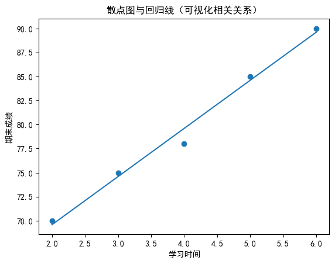

```python
# 散点图 + 简易回归直线（使用 matplotlib）
import matplotlib.pyplot as plt
import numpy as np

# 显示中文
# 设置支持中文的字体，例如黑体
plt.rcParams['font.sans-serif'] = ['SimHei']  # 或者 'Microsoft YaHei', 'FangSong', 'KaiTi' 等
plt.rcParams['axes.unicode_minus'] = False  # 解决负号显示问题

x = df['学习时间'].to_numpy(dtype=float)
y = df['期末成绩'].to_numpy(dtype=float)

# 用 numpy 最小二乘拟合直线 y = a*x + b
X_design = np.column_stack([x, np.ones_like(x)])
a, b = np.linalg.lstsq(X_design, y, rcond=None)[0]

plt.figure()
plt.scatter(x, y)            # 散点
x_line = np.linspace(x.min(), x.max(), 100)
y_line = a * x_line + b
plt.plot(x_line, y_line)     # 回归线（仅可视化）
plt.xlabel("学习时间")
plt.ylabel("期末成绩")
plt.title("散点图与回归线（可视化相关关系）")
plt.show()
```

## 11.4.3 示范：一元线性回归（用学习时间预测成绩）

```python
# 优先使用 sklearn；若不可用则自动兜底到 numpy
import numpy as np

X = np.array([2, 3, 4, 5, 6], dtype=float).reshape(-1, 1)
y = np.array([70, 75, 78, 85, 90], dtype=float)

try:
    from sklearn.linear_model import LinearRegression
    model = LinearRegression()
    model.fit(X, y)
    slope = model.coef_[0]
    intercept = model.intercept_
    r2 = model.score(X, y)
    print("回归系数（斜率）:", round(slope, 4))
    print("截距:", round(intercept, 4))
    print("R²:", round(r2, 4))
except Exception as e:
    # numpy 最小二乘兜底实现
    X_design = np.column_stack([np.ones(len(X)), X.flatten()])  # [1, x]
    beta, *_ = np.linalg.lstsq(X_design, y, rcond=None)
    intercept, slope = float(beta[0]), float(beta[1])
    y_hat = X_design @ beta
    rss = float(((y - y_hat)**2).sum())
    tss = float(((y - y.mean())**2).sum())
    r2 = 1 - rss/tss
    print("（使用 numpy 兜底）")
    print("回归系数（斜率）:", round(slope, 4))
    print("截距:", round(intercept, 4))
    print("R²:", round(r2, 4))
```

```
回归系数（斜率）: 5.0
截距: 59.6
R²: 0.9874
```

```python
# 使用模型预测（比如学习 8 小时的成绩）
X_new = np.array([[8]], dtype=float)
try:
    predicted = model.predict(X_new)  # 若上方是 sklearn
except NameError:
    # 若没有 sklearn 的 model，则使用兜底系数计算
    predicted = slope * X_new.flatten() + intercept
print("预测学习 8 小时的成绩:", round(float(predicted[0]), 2))
```

```
预测学习 8 小时的成绩: 99.6
```

## 11.4.4 举例（贴近人文社科的数据情境）

### 例 1：多个自变量的**多元线性回归**

假设我们用 `学习时间` 与 `练习题数量` 共同预测 `期末成绩`。

```python
import numpy as np
import pandas as pd

np.random.seed(0)
n = 12
learn_hours = np.linspace(1, 6, n)
practice = np.linspace(10, 60, n) + np.random.normal(0, 5, n)
score = 55 + 4.0*learn_hours + 0.05*practice + np.random.normal(0, 2, n)

X_multi = np.column_stack([learn_hours, practice])
y_multi = score

try:
    from sklearn.linear_model import LinearRegression
    m2 = LinearRegression().fit(X_multi, y_multi)
    print("斜率（学习时间, 练习题）:", np.round(m2.coef_, 3))
    print("截距:", round(m2.intercept_, 3))
    print("R²:", round(m2.score(X_multi, y_multi), 4))
except Exception as e:
    X_design = np.column_stack([np.ones(len(X_multi)), X_multi])
    beta, *_ = np.linalg.lstsq(X_design, y_multi, rcond=None)
    intercept, b1, b2 = beta
    y_hat = X_design @ beta
    rss = float(((y_multi - y_hat)**2).sum())
    tss = float(((y_multi - y_multi.mean())**2).sum())
    r2 = 1 - rss/tss
    print("（numpy 兜底）")
    print("斜率（学习时间, 练习题）:", [round(float(b1),3), round(float(b2),3)])
    print("截距:", round(float(intercept),3))
    print("R²:", round(r2,4))
```

```
斜率（学习时间, 练习题）: [2.044 0.217]
截距: 55.487
R²: 0.9297
```

### 例 2：`corr()` 方法对比（皮尔逊 vs 斯皮尔曼）

- 当数据**偏离线性**或包含**极端值/等级数据**时，Spearman（等级相关）更稳健。

```python
df2 = pd.DataFrame({
    '学习时间': [1,2,3,4,5,6,7,8],
    '满意度_等级': [1,1,2,2,3,3,4,5]  # 等级型数据（有序分类）
})
pearson = df2.corr(method='pearson')
spearman = df2.corr(method='spearman')
pearson, spearman
```

```
(            学习时间    满意度_等级
 学习时间    1.000000  0.973479
 满意度_等级  0.973479  1.000000,
             学习时间    满意度_等级
 学习时间    1.000000  0.981981
 满意度_等级  0.981981  1.000000)
```

## 11.4.5 回归模型对比与应用（速查表）

| 回归类型 | Python方法 | 常见应用场景 |
| --- | --- | --- |
| 线性回归 | `LinearRegression` | 简单线性关系预测 |
| 多元回归 | `LinearRegression` | 多因素联合分析 |
| 岭回归 | `Ridge` | 多重共线性、系数收缩 |
| 套索回归 | `Lasso` | 稀疏选择/特征选择 |
| 逻辑回归 | `LogisticRegression` | 二分类问题（通过/未通过） |
| 多项式回归 | `PolynomialFeatures + LinearRegression` | 简单非线性趋势 |
| 决策树回归 | `DecisionTreeRegressor` | 非线性、可解释的分段模型 |
| 随机森林回归 | `RandomForestRegressor` | 高维、非线性、鲁棒预测 |
| 支持向量回归 | `SVR` | 小样本、非线性核方法 |

## 11.4.6 注意事项（常见坑）

1. **相关 ≠ 因果**：相关可能来自共同原因、混杂变量或巧合。
2. **线性假设**：若关系明显弯曲，简单线性模型会失真；可尝试多项式/树模型。
3. **异常值影响大**：单个极端点能显著改变斜率/相关；先画图检查。
4. **外推风险**：超出训练数据范围的预测不可靠。
5. **多重共线性**：多元回归中自变量高度相关会导致系数不稳定，需诊断（如方差膨胀因子 VIF，进阶）。

## 11.4.7 练习（建议先做再看答案）

**练习 1：相关性**  
构造数据：`学习时间=[1,2,3,4,5,6]`，`成绩=[60,65,68,74,80,85]`。  
1) 计算皮尔逊相关系数与相关矩阵；2) 画散点图 + 回归直线。

**练习 2：一元回归预测**  
用练习 1 的数据拟合回归，报告**斜率、截距、R²**；预测 `学习时间=7` 时的成绩。

**练习 3：多元回归**  
自拟 `练习题数量` 列，与 `学习时间` 一起预测 `成绩`；比较一元与多元模型的 R²。

**练习 4：Spearman 等级相关**  
构造一列**等级型**满意度（1~5），计算与学习时间的 Spearman 相关并解释。

```python
# === 在此动手做题（你可以多建几个单元格）===
import numpy as np
import pandas as pd
import matplotlib.pyplot as plt

# 练习 1：相关性与散点图


# 练习 2：一元回归（报告 斜率/截距/R² + 预测）


# 练习 3：多元回归（与一元回归比较 R²）


# 练习 4：Spearman 等级相关
```

## 11.4.8 参考答案（对照自检）

> 说明：若无 `sklearn`，答案会自动切换为 `numpy` 兜底实现。

```
相关矩阵：
          学习时间        成绩
学习时间  1.000000  0.996085
成绩    0.996085  1.000000
```

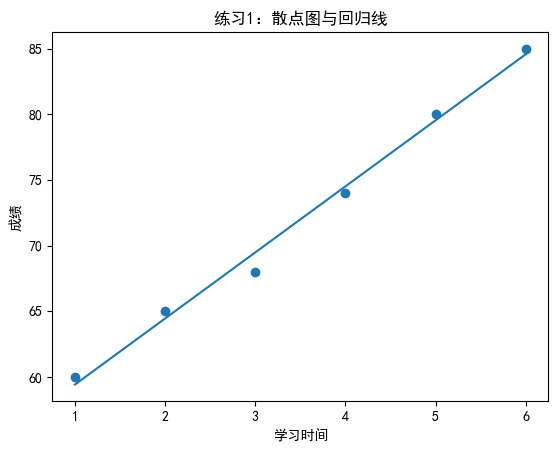

```python
# 练习 1 参考答案
import numpy as np
import pandas as pd
import matplotlib.pyplot as plt

df_ex = pd.DataFrame({
    '学习时间': [1,2,3,4,5,6],
    '成绩': [60,65,68,74,80,85]
})

print("相关矩阵：")
print(df_ex.corr())

x = df_ex['学习时间'].to_numpy(dtype=float)
y = df_ex['成绩'].to_numpy(dtype=float)
X_design = np.column_stack([x, np.ones_like(x)])
a, b = np.linalg.lstsq(X_design, y, rcond=None)[0]

plt.figure()
plt.scatter(x, y)
x_line = np.linspace(x.min(), x.max(), 100)
y_line = a*x_line + b
plt.plot(x_line, y_line)
plt.xlabel("学习时间")
plt.ylabel("成绩")
plt.title("练习1：散点图与回归线")
plt.show()
```

```python
# 练习 2 参考答案：一元回归 + 预测
import numpy as np

X = np.array([1,2,3,4,5,6], dtype=float).reshape(-1,1)
y = np.array([60,65,68,74,80,85], dtype=float)

try:
    from sklearn.linear_model import LinearRegression
    m = LinearRegression().fit(X, y)
    slope, intercept = m.coef_[0], m.intercept_
    r2 = m.score(X, y)
    pred7 = m.predict(np.array([[7]], dtype=float))[0]
except Exception as e:
    Xd = np.column_stack([np.ones(len(X)), X.flatten()])
    beta, *_ = np.linalg.lstsq(Xd, y, rcond=None)
    intercept, slope = float(beta[0]), float(beta[1])
    y_hat = Xd @ beta
    rss = float(((y - y_hat)**2).sum()); tss = float(((y - y.mean())**2).sum())
    r2 = 1 - rss/tss
    pred7 = slope*7 + intercept

print("斜率:", round(slope,4), "截距:", round(intercept,4), "R²:", round(r2,4))
print("预测（学习时间=7）:", round(float(pred7), 2))
```

```
斜率: 5.0286 截距: 54.4 R²: 0.9922
预测（学习时间=7）: 89.6
```

```python
# 练习 3 参考答案：多元回归 vs 一元回归
import numpy as np
from numpy.random import default_rng

rng = default_rng(0)
learn = np.array([1,2,3,4,5,6], dtype=float)
practice = np.array([10,20,30,40,45,55], dtype=float) + rng.normal(0, 2, 6)
score = 55 + 4.0*learn + 0.05*practice + rng.normal(0, 1.5, 6)

X1 = learn.reshape(-1,1)
X2 = np.column_stack([learn, practice])

def fit_ols(X, y):
    try:
        from sklearn.linear_model import LinearRegression
        m = LinearRegression().fit(X, y)
        r2 = m.score(X, y)
        return r2
    except Exception as e:
        Xd = np.column_stack([np.ones(len(X)), X])
        beta, *_ = np.linalg.lstsq(Xd, y, rcond=None)
        y_hat = Xd @ beta
        rss = float(((y - y_hat)**2).sum()); tss = float(((y - y.mean())**2).sum())
        return 1 - rss/tss

r2_simple = fit_ols(X1, score)
r2_multi = fit_ols(X2, score)

print("一元回归 R²:", round(r2_simple, 4))
print("多元回归 R²:", round(r2_multi, 4))
```

```
一元回归 R²: 0.9769
多元回归 R²: 0.9838
```

```python
# 练习 4 参考答案：Spearman 等级相关
import pandas as pd

df_rank = pd.DataFrame({
    '学习时间': [1,2,3,4,5,6,7,8],
    '满意度': [1,1,2,2,3,3,4,5]  # 有序类别
})
spearman_corr = df_rank.corr(method='spearman')
spearman_corr
```

|  | 学习时间 | 满意度 |
| --- | --- | --- |
| 学习时间 | 1.000000 | 0.981981 |
| 满意度 | 0.981981 | 1.000000 |

## 11.4 小结

- **相关性**衡量“是否一起变动”，**回归**进一步量化“如何变动并预测”。
- 先看**散点图**，再做结论；报告时写清方法、样本量、R²/系数与解释。
- 别把相关当因果；注意异常值与外推风险。

> 下一步建议：学习残差诊断、方差膨胀因子（VIF）、正则化回归（Ridge/Lasso），和非线性模型（树/核方法）。